# Straws-Sample-Intro

Jose Rico

April 09, 2020

# Background

For this activity, you will be exploring sampling using R. We will be sampling a population of 2500 virtual straws from the dataframe `straws`.

- Our parameter (of the population) of interest is **What is the proportion of blue straws in our population?**
- `straws` is a dataframe of 2500 virtual straws of six colors (blue, green, orange, purple, red and yellow).

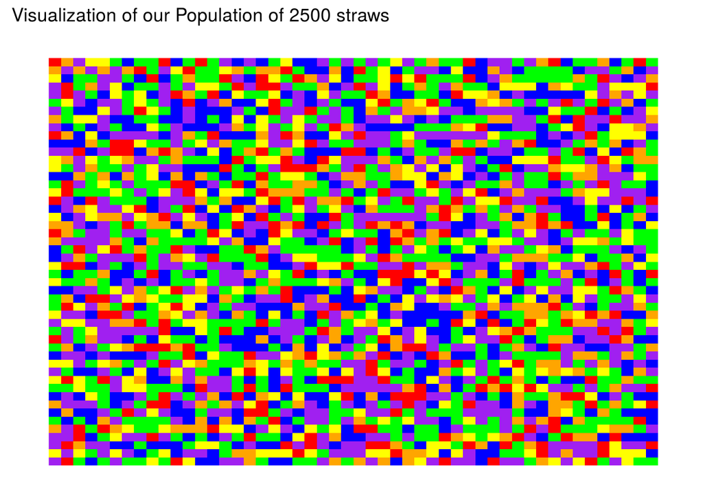

# Data Frame Details

Our `straws` dataframe has 1 main variables of interest

- **color** - color of the individual straw

A sample of 5 rows in `straws` dataframe  
(note: **x_pos** and **y_pos** are variables used to create the tiling visualization with `geom_raster`)

| x_pos | y_pos | color |
| --- | --- | --- |
| 7 | 42 | blue |
| 36 | 9 | blue |
| 19 | 49 | orange |
| 38 | 35 | orange |
| 34 | 41 | purple |

# Sampling

We can take a single sample of straws in R, using the `sample_n` function in R. The `sample_n` function has two parameters of interest for us.

- The `size = 50` argument defines how many rows to sample from the `straws` dataframe.
- The `replace = F` argument, tells R to keep selecting rows without replacing selections.
  - This means that once a row is selected it can not be re-selected, this is called **sampling without replacement**.

After taking the sample, we create a quick tabulation of our `sample1`’s **color** variable.

```r
set.seed(1123581321)
sample1 <- straws %>%
  sample_n(size = 50, replace = F )

sample1 %>% tabyl(color)
```

```
##   color  n percent
##    blue 12    0.24
##   green 10    0.20
##  orange  5    0.10
##  purple 11    0.22
##     red  4    0.08
##  yellow  8    0.16
```

### **Prompt 1** - Do you think the percent of blue straws that you just obtained is the actual percent for the proportion of blue straws? Why or why not? Is it close? How close?

> hello

### **Prompt 2** - How could improve your insight into the proportion of blue straws?

> something new

# Sampling Distribution

In order to better understand the variability in random samples, it is useful to simulate multiple random samples from the same population. After obtaining multiple samples, we will create a visualization (histogram) displaying the results of all the random samples. Then we will analyze the histogram which describes the distribution of simulation.

## Simulating Multiple Random Samples

In order to simulate multiple random samples, we will use the `rep_sample_n` from the `infer` package. The `rep_sample_n` function has three parameters of interest for us. We will sample from `straws` and put the samples into a new dataframe `samples_n50_reps1000`.

- The `reps = 1000`argument defines how many samples to collect.
- The `size = 50` argument defines how many rows to sample from the `straws` dataframe.
- The `replace = F` argument, tells R to keep selecting rows without replacing selections.

```r
samples_n50_reps1000 <- straws %>%
        rep_sample_n(size = 50, reps = 1000, replace = F)
```

## Summarizing our Samples

We are interested in the proportion of blue straws in each sample, so we need to instruct R to calculate the sample proportion for each individual sample of 50.

1. First we will `group_by` according to each sample (**replicate** in our dataframe).
2. Then we’ll use the `summarize` command to count the number of blue straws in each sample.
3. Finally, `mutate` a new column, **prop_blue**, which is the result of the calculation of the proportion of blue straws for each of the 1000 random sample of 50 straws.

```r
summary_n50_reps1000 <- samples_n50_reps1000 %>%

          group_by(replicate) %>%

          summarize(blue = sum(color == "blue")) %>%

          mutate(prop_blue = blue/ 50)
```

## Visualization the color composition of our samples

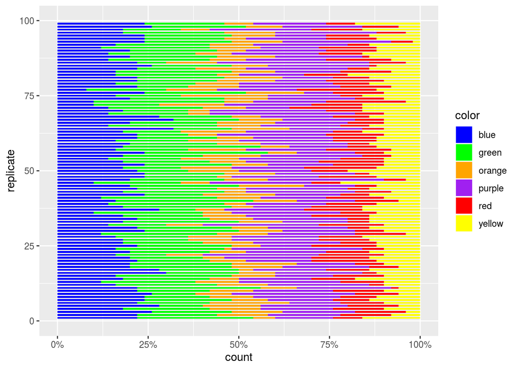

```r
samples_n50_reps1000 %>%
  ggplot(aes(fill=color, x=replicate))+
    geom_bar(position = position_fill(reverse = T), width=0.6) +
    scale_y_continuous(labels=percent) +
    xlim(0,100)+
    scale_colour_manual(values = c("blue","green" ,"orange", "purple", "red", "yellow"), aesthetics = c("colour", "fill"))+
    coord_flip()
```

## Visualizing the Distribution of Sample Proportions

Now, we will visualize the 1000 random samples’ proportion of blue straws in a histogram.

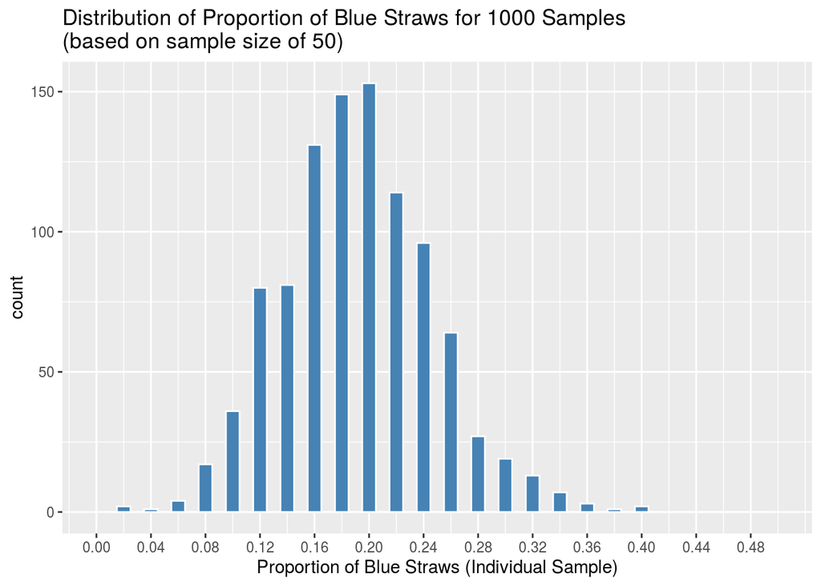

```r
summary_n50_reps1000 %>%

  ggplot(aes(prop_blue)) +

  geom_histogram(binwidth = 0.01,
                 color="white",
                 fill="steelblue") +

  labs(x = "Proportion of Blue Straws (Individual Sample)",
       title ="Distribution of Proportion of Blue Straws for 1000 Samples \n(based on sample size of 50)") +


    scale_x_continuous(limits = c(0, 0.5), breaks = seq(0,0.5,0.04))
```

### **Prompt 7** - What insights have you been able to gather regarding sampling’s ability to gain information about a population?

# Post Activity - Study Effect of Increasing Sample Size

We have just demonstrated the process of constructing a hypothetical sampling distribution for sample size of 50. Next step is to see the effect of increasing the sample size on the sampling distribution. The following code is a single chunk that simulates, summarizes and visualizes for a sample size of 100

## Sample Size = 100

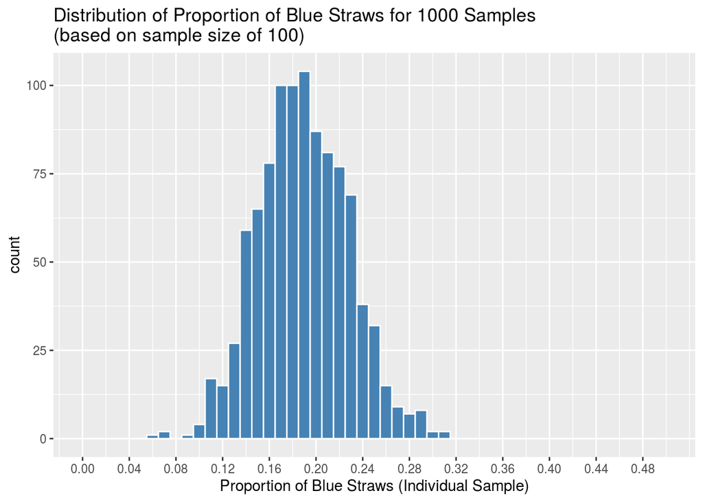

```r
n = 100

straws %>%
        rep_sample_n(size = n, reps = 1000, replace = F) %>%

          group_by(replicate) %>%

          summarize(blue = sum(color == "blue")) %>%

          mutate(prop_blue = blue/ n)  %>%

ggplot(aes(prop_blue)) +

    geom_histogram(binwidth = 0.01,
                 color="white",
                 fill="steelblue") +

      labs(x = "Proportion of Blue Straws (Individual Sample)",
          title ="Distribution of Proportion of Blue Straws for 1000 Samples \n(based on sample size of 100)") +

    scale_x_continuous(limits = c(0, 0.5), breaks = seq(0,0.5,0.04))
```

## Sample Size = 200

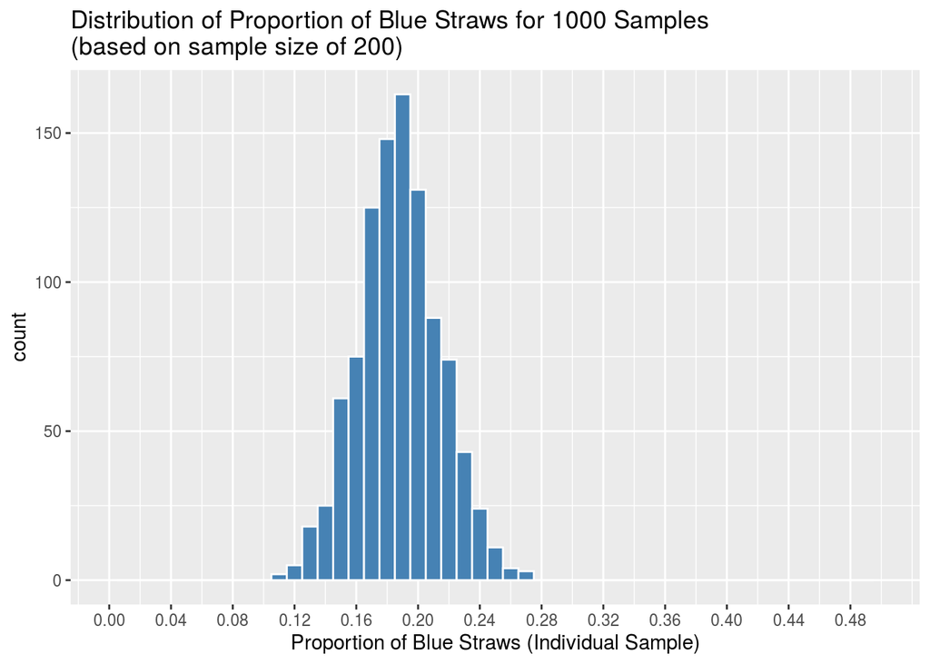